# Heart Disease Prediction

### بِسْمِ ٱللَّٰهِ ٱلرَّحْمَٰنِ ٱلرَّحِيمِ

```
*----------------------------- AUTHOR_DETAILS -------------------------------*
|                                                                            |
|        Project Title  = Heart Disease Prediction System                    |
|                                                                            |
|        Author         = Ms. Muryam Naveed                                  |
|                                                                            |
|        Copyright      = Copyright (C) 2024 Ms. Muryam Naveed               |
|                                                                            |
|        License        = Public Domain                                      |
|                                                                            |
|        Version        = 1.0                                                |
|                                                                            |
*----------------------------------------------------------------------------*
```

## PROJECT PURPOSE

### The main purpose of this project is to demonstrate how the heart disease prediction problem can be treated as a supervised machine learning problem using Python and the Scikit-learn toolkit.

### For this purpose, we will execute the machine learning cycle.

# Heart Disease Prediction System

This notebook demonstrates how to build a heart disease prediction system using Python and Scikit-learn.

## Assignment Requirements Overview:

The assignment involves developing a Heart Disease Prediction System by adapting the code from the Titanic Passenger Survival Prediction System. Key steps include:

1. **Reading and Understanding Provided Lectures**
2. **Running the Titanic Code**
3. **Adapting the Code for Heart Disease Prediction**

## Phases of the System

The machine learning cycle to be followed:

### 1. Training Phase:

- Build the model using training data.

### 2. Testing Phase:

- Evaluate the performance of the model using testing data.

### 3. Application Phase:

- Deploy the model to predict real-time unseen data.

### 4. Feedback Phase:

- Collect feedback to improve the model.

## Steps to Build Heart Disease Prediction System

### Step 1: Import Libraries

- Import necessary libraries for data manipulation, visualization, and machine learning.
- Example: `import pandas as pd`, `import numpy as np`, `from sklearn.model_selection import train_test_split`, etc.

### Step 2: Load the Dataset

- Load the heart disease dataset using pandas.
- Example: `heart_data = pd.read_csv("path/to/heart-disease-dataset.csv")`

### Step 3: Data Preprocessing

- Handle missing values: Fill or drop missing data as necessary.
- Encode categorical variables: Use label encoding or one-hot encoding for categorical features.
- Normalize numerical features: Scale numerical features to a standard range if necessary.

### Step 4: Exploratory Data Analysis (EDA)

- Visualize the data: Use plots to understand the distribution of features.
- Correlation analysis: Identify correlations between features and the target variable.

### Step 5: Feature Selection

- Select relevant features: Choose features that are most relevant for predicting heart disease.
- Dimensionality reduction: Use techniques like PCA if necessary to reduce the number of features.

### Step 6: Execute the Training Phase

- Split the dataset into training and testing sets.
- Example: `X_train, X_test, y_train, y_test = train_test_split(X, y, test_size=0.2, random_state=0)`

### Step 7: Model Selection and Training

- Choose a machine learning model: Select models like Logistic Regression, SVM, Random Forest, etc.
- Train the model: Fit the model on the training data.
- Example: `model = LogisticRegression()`, `model.fit(X_train, y_train)`

### Step 8: Model Evaluation

- Evaluate the model performance on the test set.
- Use metrics like accuracy, precision, recall, F1-score.
- Example: `accuracy = model.score(X_test, y_test)`

### Step 9: Execute the Application Phase

- Take input from user
- Preprocess the input
- Save the trained model using joblib or pickle.
- Load the model and use it to make predictions on new data.
- Example: `import pickle`, `pickle.dump(model, open("model.pkl", "wb"))`

### Step 10: Execute the Feedback Phase

- Take feedback from domain experts

### Step 11: Improve Model based on Feedback

- Monitor the model performance over time.
- Update the model with new data periodically.
- Retrain the model if necessary to maintain accuracy.

### Step 12: Additional Model Evaluation and Optimization

- Optimize model performance by tuning hyperparameters using Grid Search or Random Search.
- Example: `from sklearn.model_selection import GridSearchCV`, `grid_search = GridSearchCV(estimator=model, param_grid=param_grid, scoring='accuracy', cv=10)`

### Conclusion

- Building a heart disease prediction system involves several steps from data preprocessing to model deployment.
- Each step is crucial for building a reliable and accurate prediction system that can assist in early detection and prevention of heart disease.

# Step 1: Import Libraries

```python
# Import Libraries
import numpy as np
import pandas as pd
import pickle
from sklearn.model_selection import train_test_split
from sklearn.preprocessing import LabelEncoder, StandardScaler
from sklearn import svm
from sklearn.metrics import accuracy_score, confusion_matrix, classification_report, roc_curve, auc
from sklearn.model_selection import GridSearchCV, cross_val_score
from sklearn.ensemble import RandomForestClassifier
from sklearn.linear_model import LogisticRegression
from sklearn.neighbors import KNeighborsClassifier
from sklearn.utils import resample
import matplotlib.pyplot as plt
from prettytable import PrettyTable
```

# Step 2: Load Heart Disease Data

```python
# Load Heart Disease Data
heart_data = pd.read_csv("heart-disease-sample-data.csv")
print("Heart Disease Data:\n====================\n", heart_data.head())
pd.set_option("display.max_rows", None, "display.max_columns", None)
```

```
Heart Disease Data:
====================
    age  sex  cp  trestbps  chol  fbs  restecg  thalach  exang  oldpeak  slope
0   63    1   3       145   233    1        0      150      0      2.3      0  \
1   37    1   2       130   250    0        1      187      0      3.5      0
2   41    0   1       130   204    0        0      172      0      1.4      2
3   56    1   1       120   236    0        1      178      0      0.8      2
4   57    0   0       120   354    0        1      163      1      0.6      2

   ca  thal  target
0   0     1       1
1   0     2       1
2   0     2       1
3   0     2       1
4   0     2       1
```

# Step 3: Understand and Pre-process Sample Data

## Step 3.1: Understand Sample Data

```python
# Understand Sample Data
print("\n\nAttributes in Heart Disease Data:")
print("=================================\n")
print(heart_data.columns)

print("\n\nNumber of Instances in Heart Disease Data:", heart_data.shape[0])
print("==============================================\n")
```

```
Attributes in Heart Disease Data:
=================================

Index(['age', 'sex', 'cp', 'trestbps', 'chol', 'fbs', 'restecg', 'thalach',
       'exang', 'oldpeak', 'slope', 'ca', 'thal', 'target'],
      dtype='object')


Number of Instances in Heart Disease Data: 100
==============================================
```

## Step 3.2: Pre-process Sample Data

1. **Handle Missing Values:**
   - Identify and fill missing values.

```python
# Handle Missing Values
heart_data.fillna(method='ffill', inplace=True)
```

2. **Encode Categorical Variables:**
   - Identify categorical variables and apply label encoding.

```python
# Identify Categorical Features
categorical_features = ['sex', 'cp', 'fbs', 'restecg', 'exang', 'slope', 'ca', 'thal']

# Initialize Label Encoders
encoders = {feature: LabelEncoder() for feature in categorical_features}

# Encode Categorical Features
for feature in categorical_features:
    heart_data[feature] = encoders[feature].fit_transform(heart_data[feature])
```

3. **Encode the Target Variable:**

```python
# Encode Target Variable
target_encoder = LabelEncoder()
heart_data['target'] = target_encoder.fit_transform(heart_data['target'])
```

4. **Standardize Numerical Features:**
   - Scale numerical features to a standard range.

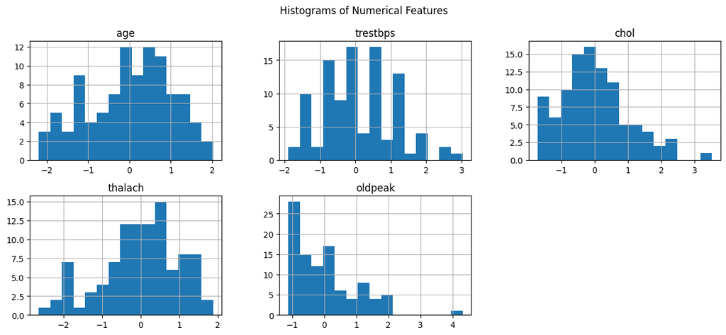

```python
# Standardize Numerical Features
scaler = StandardScaler()
numerical_features = ['age', 'trestbps', 'chol', 'thalach', 'oldpeak']
heart_data[numerical_features] = scaler.fit_transform(heart_data[numerical_features])

# Histograms for numerical features
heart_data[numerical_features].hist(bins=15, figsize=(15, 6), layout=(2, 3))
plt.suptitle('Histograms of Numerical Features')
plt.show()
```

##### Boxplots:

Identify outliers and understand the distribution of numerical features.

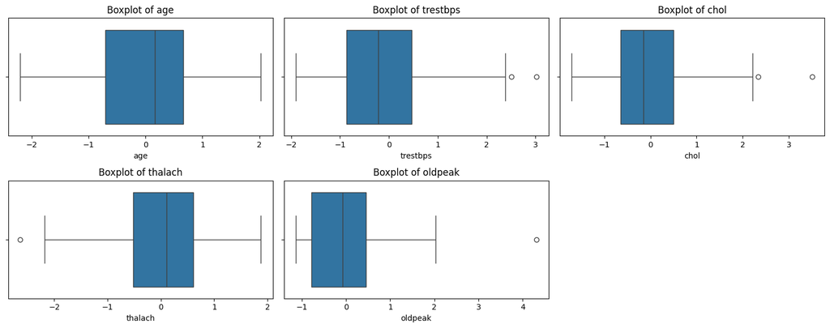

```python
# Boxplots for numerical features
plt.figure(figsize=(15, 6))
for i, feature in enumerate(numerical_features):
    plt.subplot(2, 3, i+1)
    sns.boxplot(x=heart_data[feature])
    plt.title(f'Boxplot of {feature}')
plt.tight_layout()
plt.show()
```

5. **Handle Outliers:**
   - Identify and handle outliers if necessary.

```python
# Handle Outliers
for feature in numerical_features:
    q1 = heart_data[feature].quantile(0.25)
    q3 = heart_data[feature].quantile(0.75)
    iqr = q3 - q1
    lower_bound = q1 - 1.5 * iqr
    upper_bound = q3 + 1.5 * iqr
    heart_data = heart_data[(heart_data[feature] >= lower_bound) & (heart_data[feature] <= upper_bound)]
```

# Step 4: Exploratory Data Analysis (EDA)

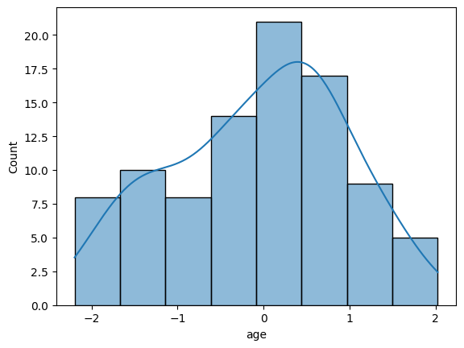

```python
# Visualize Age Distribution
sns.histplot(heart_data['age'], kde=True)
plt.show()
```

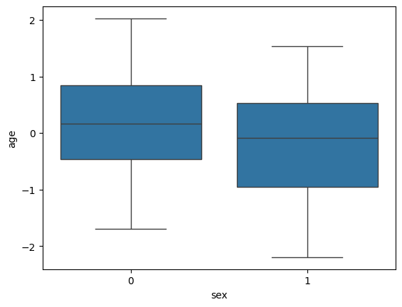

```python
# Boxplot for Age and Sex
sns.boxplot(x='sex', y='age', data=heart_data)
plt.show()
```

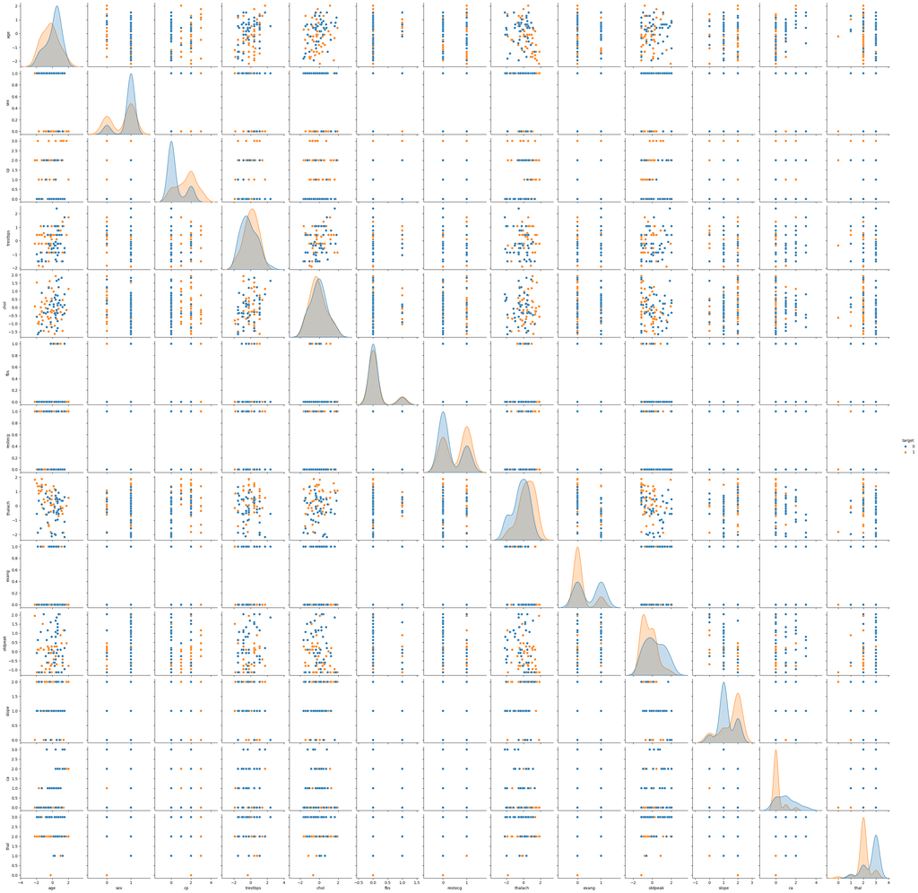

```python
# Pairplot for the Dataset
sns.pairplot(heart_data, hue='target')
plt.show()
```

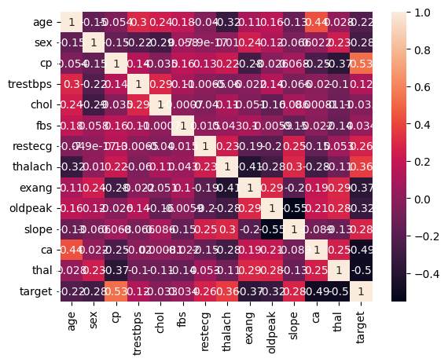

```python
# Correlation Matrix
correlation_matrix = heart_data.corr()
sns.heatmap(correlation_matrix, annot=True)
plt.show()
```

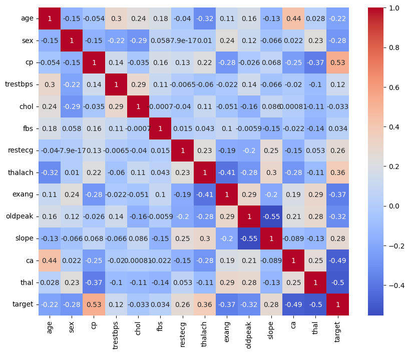

```python
# Correlation heatmap
plt.figure(figsize=(10, 8))
sns.heatmap(heart_data.corr(), annot=True, cmap='coolwarm')
plt.show()
```

# Step 5: Feature Selection

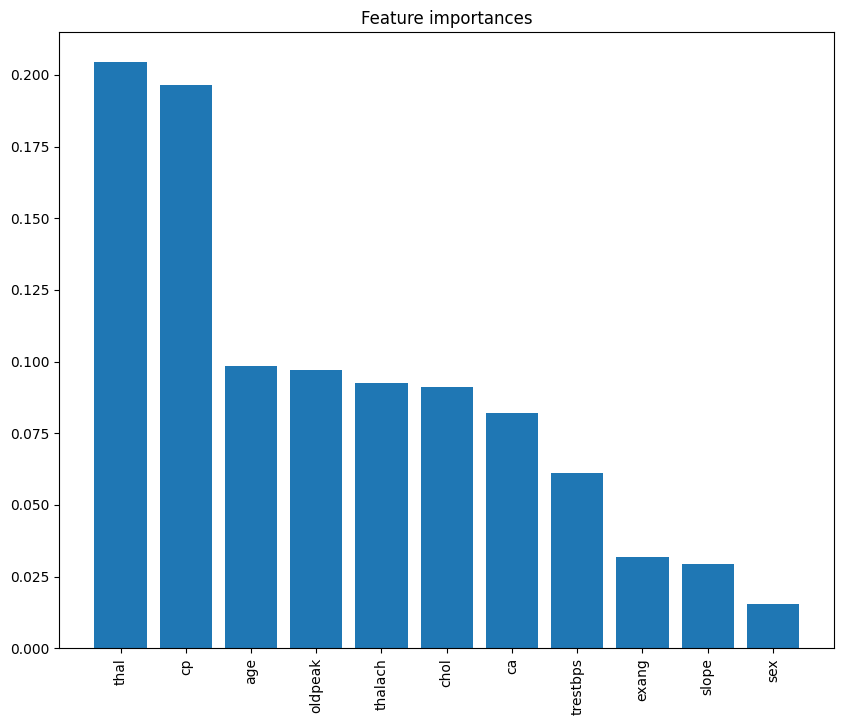

```
Top 4 Features: ['thal', 'cp', 'ca', 'thalach']
```

```python
# Feature Extraction: Select relevant features based on correlation or domain knowledge
selected_features = ['age', 'sex', 'cp', 'trestbps', 'chol', 'thalach', 'exang', 'oldpeak', 'slope', 'ca', 'thal']

X = heart_data[selected_features]
y = heart_data['target']

# Splitting the dataset before feature selection
X_train, X_test, y_train, y_test = train_test_split(X, y, test_size=0.2, random_state=0)

# Feature selection using Random Forest
model = RandomForestClassifier()
model.fit(X_train, y_train)

importances = model.feature_importances_
indices = np.argsort(importances)[::-1]

plt.figure(figsize=(10, 8))
plt.title("Feature importances")
plt.bar(range(X_train.shape[1]), importances[indices], align="center")
plt.xticks(range(X_train.shape[1]), [X_train.columns[i] for i in indices], rotation=90)
plt.show()

# Identify top 4 features using Random Forest
rf_model = RandomForestClassifier(random_state=0)
rf_model.fit(X, y)

feature_importances = rf_model.feature_importances_
features = X.columns

importance_df = pd.DataFrame({
    'Feature': features,
    'Importance': feature_importances
}).sort_values(by='Importance', ascending=False)

top_4_features = importance_df['Feature'].head(4).tolist()
print("Top 4 Features:", top_4_features)

X_top4 = X[top_4_features]
```

### Explanation of Top 4 Features

# Step 6: Execute the Training Phase

## Step 6.1: Splitting Sample Data into Training Data and Testing Data

```python
# Split the Dataset into Training and Testing Sets
X_train, X_test, y_train, y_test = train_test_split(X, y, test_size=0.2, random_state=0)

# Split the Dataset into Training and Testing Sets for top 4 features
# X_train, X_test, y_train, y_test = train_test_split(X_top4, y, test_size=0.2, random_state=0)
```

## Step 6.2: Splitting Input Vectors and Outputs / Labels of Training Data

- Already done in Step 6.1.

```python
# Splitting Input Vectors and Outputs/Labels of Training Data
print("Training Data Input Vectors (X_train):")
print(X_train.head())

print("Training Data Labels (y_train):")
print(y_train.head())
```

```
Training Data Input Vectors (X_train):
         age  sex  cp  trestbps      chol   thalach  exang   oldpeak  slope
33 -0.085707    1   2 -0.539680  0.541432  0.051241      0 -0.692226      0  \
45 -0.334132    1   1 -0.863618  1.614393  1.065921      0 -0.955764      2
58  0.411144    1   2 -0.086167 -0.469627  1.116655      0  1.679614      2
7  -1.327834    1   1 -0.863618  0.335094  1.116655      0 -1.131456      2
47 -0.955195    1   2  0.302558  0.211291  0.254177      0 -1.131456      2

    ca  thal
33   1     2
45   0     2
58   2     3
7    0     3
47   0     2
Training Data Labels (y_train):
33    1
45    1
58    0
7     1
47    1
Name: target, dtype: int64
```

# Step 7: Model Selection and Training

## Step 7.1: Train the Support Vector Classifier

```python
# Train the Support Vector Classifier
model = svm.SVC(gamma='auto', random_state=0)
model.fit(X_train, y_train)


# Re-train the model with selected features
# model.fit(X_train, y_train)

# Save the Model
# pickle.dump(model, open('heart_disease_model.pkl', 'wb'))
```

```
SVC(gamma='auto', random_state=0)
```

## Step 7.2: Save the Trained Model

```python
# Save the trained model to a file
pickle.dump(model, open('heart_disease_model.pkl', 'wb'))
print("Model saved to heart_disease_model.pkl")
```

```
Model saved to heart_disease_model.pkl
```

# Step 8: Model Evaluation

## Step 8.1: Splitting Input Vectors and Outputs/Labels of Testing Data

- Already done in Step 6.1.

```python
# Splitting Input Vectors and Outputs/Labels of Testing Data
X_test_input = X_test
y_test_output = y_test

print("Testing Data Input Vectors (X_test):")
print(X_test_input.head())

print("Testing Data Labels (y_test):")
print(y_test_output.head())
```

```
Testing Data Input Vectors (X_test):
         age  sex  cp  trestbps      chol   thalach  exang   oldpeak  slope
2  -1.700472    0   1 -0.215743 -0.882304  1.065921      0  0.098387      2  \
36 -0.085707    0   2  0.108195  1.181082  0.964453      0 -1.131456      2
24 -1.824684    1   3  0.432133 -0.985473  1.370325      1  0.098387      2
18 -1.452046    1   0  1.080009  0.004952  1.015187      0  0.186233      2
15 -0.582557    0   2 -0.863618 -0.572796  0.355645      0  0.274079      1

    ca  thal
2    0     2
36   0     2
24   0     3
18   0     2
15   0     2
Testing Data Labels (y_test):
2     1
36    1
24    1
18    1
15    1
Name: target, dtype: int64
```

## Step 8.2: Load the Saved Model

```python
# Load the Trained Model
model = pickle.load(open('heart_disease_model.pkl', 'rb'))
print("Model loaded from heart_disease_model.pkl")
```

```
Model loaded from heart_disease_model.pkl
```

## Step 8.3: Evaluate the Machine Learning Model

### Step 8.3.1: Make Predictions with the Trained Models on Testing Data

```python
# Make Predictions with the Trained Model on Testing Data
predictions = model.predict(X_test_input)
```

## Step 8.4: Calculate the Accuracy Score

```python
# Calculate the Accuracy Score
accuracy = accuracy_score(y_test_output, predictions)
print(f"Model Accuracy: {accuracy:.2f}")
```

```
Model Accuracy: 0.74
```

# Step 9: Execute the Application Phase

## Step 9.1: Take Input from User

```python
# Take User Input for Prediction
user_input = {
    'age': 45,
    'sex': 1,
    'cp': 2,
    'trestbps': 120,
    'chol': 200,
    'fbs': 0,
    'restecg': 1,
    'thalach': 150,
    'exang': 0,
    'oldpeak': 1.0,
    'slope': 2,
    'ca': 0,
    'thal': 2
}

# User Input Function
def get_user_input():
    print("Please enter the following details for prediction:")
    user_input = {}
    user_input['age'] = float(input("Age: "))
    user_input['sex'] = int(input("Sex (1 = male, 0 = female): "))
    user_input['cp'] = int(input("Chest Pain Type (0, 1, 2, 3): "))
    user_input['trestbps'] = float(input("Resting Blood Pressure: "))
    user_input['chol'] = float(input("Serum Cholesterol (mg/dl): "))
    user_input['thalach'] = float(input("Maximum Heart Rate Achieved: "))
    user_input['exang'] = int(input("Exercise Induced Angina (1 = yes, 0 = no): "))
    user_input['oldpeak'] = float(input("ST Depression Induced by Exercise: "))
    user_input['slope'] = int(input("Slope of the Peak Exercise ST Segment (0, 1, 2): "))
    user_input['ca'] = int(input("Number of Major Vessels (0-3): "))
    user_input['thal'] = int(input("Thalassemia (1 = normal, 2 = fixed defect, 3 = reversable defect): "))
    return user_input

# Take User Input for Prediction
# user_input = get_user_input()
```

## Step 9.2: Convert User Input into Feature Vector (Exactly Same as Feature Vectors of Sample Data)

```python
# Convert User Input into Feature Vector
user_input_df = pd.DataFrame(user_input, index=[0])
```

## Step 9.3: Label Encoding of Feature Vector (Exactly Same as Label Encoded Feature Vectors of Sample Data)

```python
# Encode and Normalize User Input
for feature in categorical_features:
    if feature in user_input_df.columns:
        user_input_df[feature] = encoders[feature].transform(user_input_df[feature])

user_input_df[numerical_features] = scaler.transform(user_input_df[numerical_features])
```

## Step 9.4: Load the Saved Model

```python
# Load the Trained Model
model = pickle.load(open('heart_disease_model.pkl', 'rb'))
print("Model loaded from heart_disease_model.pkl")
```

```
Model loaded from heart_disease_model.pkl
```

## Step 9.5: Model Prediction

### Step 8.5.1: Apply Model on the Label Encoded Feature Vector of unseen instance and return Prediction to the User

```python
# Ensure the order of columns matches the training data
user_input_df = user_input_df[X_train.columns]

# Select top 4 features
# user_input_top4 = user_input_df[top_4_features]

# Make Prediction
prediction = model.predict(user_input_df)
result = target_encoder.inverse_transform(prediction)
print(f"Prediction: {'Heart Disease' if result[0] == 1 else 'No Heart Disease'}")

# Select top 4 features
user_input_top4 = user_input_df[top_4_features]
```

```
Prediction: Heart Disease
```

# Step 10: Execute the Feedback Phase

## A Two-Step Process

### Step 01: After some time, take Feedback from

```
o	Domain Experts and Users.
```

### Step 02: Make a List of Possible Improvements based on Feedback received

# Step 11: Improve Model based on Feedback

### There is Always Room for Improvement

### Based on Feedback from Domain Experts and Users

```
o	Improve your Model
```

### Model Monitoring and Maintenance

1. **Monitor Performance**:

```python
# def monitor_performance(model, X_test, y_test):
#     y_pred = model.predict(X_test)
#     accuracy = accuracy_score(y_test, y_pred)
#     print("Current Model Accuracy:", accuracy)
#     return accuracy

# # Example usage:
# monitor_performance(model, X_test, y_test)
```

2. **Retrain the Model with New Data**:

```python
# def retrain_model(new_data, model):
#     X_new = new_data[top_4_features]
#     y_new = new_data['target']
#     model.fit(X_new, y_new)
#     return model

# # Example usage:
# new_data = pd.read_csv("new-heart-disease-data.csv")
# model = retrain_model(new_data, model)
```

3. **Feedback Loop**:

```python
# # Assuming you get feedback in the form of incorrect predictions:
# def update_model_with_feedback(model, X_feedback, y_feedback):
#     model.fit(X_feedback, y_feedback)
#     return model

# # Example usage:
# feedback_data = pd.read_csv("feedback-data.csv")
# X_feedback = feedback_data[top_4_features]
# y_feedback = feedback_data['target']
# model = update_model_with_feedback(model, X_feedback, y_feedback)
```

# Step 12: Additional Model Evaluation and Optimization

By using these approaches, we can thoroughly evaluate and optimize our heart disease prediction model. This ensures that our model is accurate, reliable, and generalizes well to new data, making it a robust tool for predicting heart disease.

## Step-by-Step Approach to Improve and Evaluate the Model

### 12.1. Performance Analysis

- Use more detailed performance metrics to understand the model's strengths and weaknesses.

#### 12.1.1. Confusion Matrix

- Confusion Matrix and Classification Report

```
Confusion Matrix:
[[ 3  5]
 [ 0 11]]
Classification Report:
              precision    recall  f1-score   support

           0       1.00      0.38      0.55         8
           1       0.69      1.00      0.81        11

    accuracy                           0.74        19
   macro avg       0.84      0.69      0.68        19
weighted avg       0.82      0.74      0.70        19
```

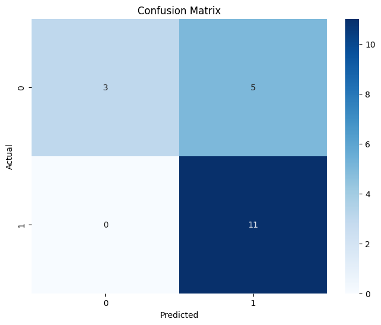

```python
# Predict on the test set
y_pred = model.predict(X_test)

# Confusion Matrix
conf_matrix = confusion_matrix(y_test, y_pred)
print("Confusion Matrix:")
print(conf_matrix)

# Classification Report
class_report = classification_report(y_test, y_pred)
print("Classification Report:")
print(class_report)

# Plot Confusion Matrix
plt.figure(figsize=(8, 6))
sns.heatmap(conf_matrix, annot=True, fmt='d', cmap='Blues')
plt.title('Confusion Matrix')
plt.xlabel('Predicted')
plt.ylabel('Actual')
plt.show()
```

#### 12.1.2. ROC Curve and AUC

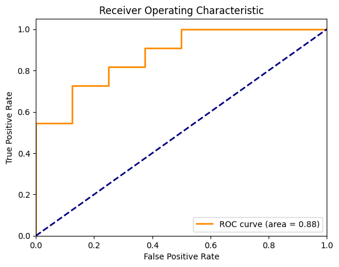

```python
# Compute ROC curve and ROC area for each class
fpr, tpr, _ = roc_curve(y_test, model.decision_function(X_test))
roc_auc = auc(fpr, tpr)

# Plot ROC curve
plt.figure()
plt.plot(fpr, tpr, color='darkorange', lw=2, label='ROC curve (area = %0.2f)' % roc_auc)
plt.plot([0, 1], [0, 1], color='navy', lw=2, linestyle='--')
plt.xlim([0.0, 1.0])
plt.ylim([0.0, 1.05])
plt.xlabel('False Positive Rate')
plt.ylabel('True Positive Rate')
plt.title('Receiver Operating Characteristic')
plt.legend(loc="lower right")
plt.show()
```

### 12.2. Hyperparameter Tuning with Grid Search

```python
# Define parameter grid
param_grid = {
    'C': [0.1, 1, 10, 100],
    'gamma': [1, 0.1, 0.01, 0.001],
    'kernel': ['rbf', 'linear']
}

# Initialize Grid Search
grid_search = GridSearchCV(svm.SVC(), param_grid, refit=True, verbose=2)
grid_search.fit(X_train, y_train)

# Print best parameters
print("Best Parameters:", grid_search.best_params_)

# Use best parameters to train the model
best_model = grid_search.best_estimator_
```

```
Fitting 5 folds for each of 32 candidates, totalling 160 fits
[CV] END .........................C=0.1, gamma=1, kernel=rbf; total time=   0.0s
[CV] END .........................C=0.1, gamma=1, kernel=rbf; total time=   0.0s
[CV] END .........................C=0.1, gamma=1, kernel=rbf; total time=   0.0s
[CV] END .........................C=0.1, gamma=1, kernel=rbf; total time=   0.0s
[CV] END .........................C=0.1, gamma=1, kernel=rbf; total time=   0.0s
[CV] END ......................C=0.1, gamma=1, kernel=linear; total time=   0.0s
[CV] END ......................C=0.1, gamma=1, kernel=linear; total time=   0.0s
[CV] END ......................C=0.1, gamma=1, kernel=linear; total time=   0.0s
[CV] END ......................C=0.1, gamma=1, kernel=linear; total time=   0.0s
[CV] END ......................C=0.1, gamma=1, kernel=linear; total time=   0.0s
[CV] END .......................C=0.1, gamma=0.1, kernel=rbf; total time=   0.0s
[CV] END .......................C=0.1, gamma=0.1, kernel=rbf; total time=   0.0s
[CV] END .......................C=0.1, gamma=0.1, kernel=rbf; total time=   0.0s
[CV] END .......................C=0.1, gamma=0.1, kernel=rbf; total time=   0.0s
[CV] END .......................C=0.1, gamma=0.1, kernel=rbf; total time=   0.0s
[CV] END ....................C=0.1, gamma=0.1, kernel=linear; total time=   0.0s
[CV] END ....................C=0.1, gamma=0.1, kernel=linear; total time=   0.0s
[CV] END ....................C=0.1, gamma=0.1, kernel=linear; total time=   0.0s
[CV] END ....................C=0.1, gamma=0.1, kernel=linear; total time=   0.0s
[CV] END ....................C=0.1, gamma=0.1, kernel=linear; total time=   0.0s
[CV] END ......................C=0.1, gamma=0.01, kernel=rbf; total time=   0.0s
[CV] END ......................C=0.1, gamma=0.01, kernel=rbf; total time=   0.0s
[CV] END ......................C=0.1, gamma=0.01, kernel=rbf; total time=   0.0s
[CV] END ......................C=0.1, gamma=0.01, kernel=rbf; total time=   0.0s
[CV] END ......................C=0.1, gamma=0.01, kernel=rbf; total time=   0.0s
[CV] END ...................C=0.1, gamma=0.01, kernel=linear; total time=   0.0s
[CV] END ...................C=0.1, gamma=0.01, kernel=linear; total time=   0.0s
[CV] END ...................C=0.1, gamma=0.01, kernel=linear; total time=   0.0s
[CV] END ...................C=0.1, gamma=0.01, kernel=linear; total time=   0.0s
[CV] END ...................C=0.1, gamma=0.01, kernel=linear; total time=   0.0s
[CV] END .....................C=0.1, gamma=0.001, kernel=rbf; total time=   0.0s
[CV] END .....................C=0.1, gamma=0.001, kernel=rbf; total time=   0.0s
[CV] END .....................C=0.1, gamma=0.001, kernel=rbf; total time=   0.0s
[CV] END .....................C=0.1, gamma=0.001, kernel=rbf; total time=   0.0s
[CV] END .....................C=0.1, gamma=0.001, kernel=rbf; total time=   0.0s
[CV] END ..................C=0.1, gamma=0.001, kernel=linear; total time=   0.0s
[CV] END ..................C=0.1, gamma=0.001, kernel=linear; total time=   0.0s
[CV] END ..................C=0.1, gamma=0.001, kernel=linear; total time=   0.0s
[CV] END ..................C=0.1, gamma=0.001, kernel=linear; total time=   0.0s
```

[output cut: 107 more lines]

```
[CV] END ...................C=100, gamma=0.01, kernel=linear; total time=   0.0s
[CV] END ...................C=100, gamma=0.01, kernel=linear; total time=   0.0s
[CV] END ...................C=100, gamma=0.01, kernel=linear; total time=   0.0s
[CV] END ...................C=100, gamma=0.01, kernel=linear; total time=   0.0s
[CV] END .....................C=100, gamma=0.001, kernel=rbf; total time=   0.0s
[CV] END .....................C=100, gamma=0.001, kernel=rbf; total time=   0.0s
[CV] END .....................C=100, gamma=0.001, kernel=rbf; total time=   0.0s
[CV] END .....................C=100, gamma=0.001, kernel=rbf; total time=   0.0s
[CV] END .....................C=100, gamma=0.001, kernel=rbf; total time=   0.0s
[CV] END ..................C=100, gamma=0.001, kernel=linear; total time=   0.0s
[CV] END ..................C=100, gamma=0.001, kernel=linear; total time=   0.0s
[CV] END ..................C=100, gamma=0.001, kernel=linear; total time=   0.0s
[CV] END ..................C=100, gamma=0.001, kernel=linear; total time=   0.0s
[CV] END ..................C=100, gamma=0.001, kernel=linear; total time=   0.0s
Best Parameters: {'C': 10, 'gamma': 0.01, 'kernel': 'rbf'}
```

### 12.3. Cross-Validation

- Use cross-validation to get a more accurate estimate of your model's performance.
- Cross-validation is used to assess the generalizability of the model.

```
Cross-Validation Scores: [0.89473684 0.84210526 0.83333333 0.72222222 0.88888889]
Mean Cross-Validation Score: 0.8362573099415205
The mean cross-validation score of 0.84 indicates that the model's performance is consistent across different subsets of the data.
```

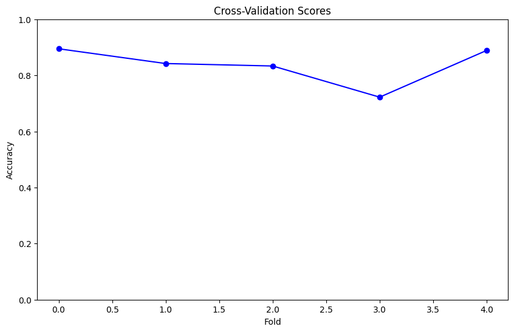

```python
# Perform cross-validation
cv_scores = cross_val_score(best_model, X, y, cv=5)

# Print cross-validation scores
print("Cross-Validation Scores:", cv_scores)
print("Mean Cross-Validation Score:", cv_scores.mean())
print(f"""The mean cross-validation score of {cv_scores.mean():.2f} indicates that the model's performance is consistent across different subsets of the data.
""")

# Plot Cross-Validation Scores
plt.figure(figsize=(10, 6))
plt.plot(cv_scores, marker='o', linestyle='-', color='b')
plt.title('Cross-Validation Scores')
plt.xlabel('Fold')
plt.ylabel('Accuracy')
plt.ylim(0, 1)
plt.show()
```

### 12.4. Try Different Models

- Experiment with other algorithms to see if they perform better.

#### Trying Different Algorithms

```python
# Initialize different models
models = {
    'SVM': best_model,
    'Random Forest': RandomForestClassifier(random_state=0),
    'Logistic Regression': LogisticRegression(max_iter=1000, random_state=0),
    'KNN': KNeighborsClassifier()
}

# Evaluate each model
for model_name, model in models.items():
    model.fit(X_train, y_train)
    predictions = model.predict(X_test)
    accuracy = accuracy_score(y_test, predictions)
    print(f"{model_name} Accuracy: {accuracy:.2f}")
```

```
SVM Accuracy: 0.74
Random Forest Accuracy: 0.74
Logistic Regression Accuracy: 0.74
KNN Accuracy: 0.74
```

### 12.6. Model Reliability

- Bootstrap sampling provides an estimate of the model's reliability.
- The mean bootstrap score indicates the average performance of the model over multiple resampled datasets.

#### Bootstrap Sampling

```
Bootstrap Scores Mean: 0.738842105263158
Bootstrap Scores Standard Deviation: 0.06455807581050235
```

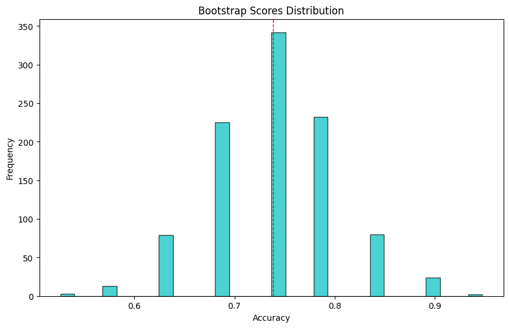

```python
# Number of bootstrap samples
n_iterations = 1000
n_size = int(len(X) * 0.50)

# Run bootstrap
scores = []
for i in range(n_iterations):
    # Prepare train and test sets
    X_resample, y_resample = resample(X, y, n_samples=n_size, random_state=i)
    model.fit(X_resample, y_resample)
    predictions = model.predict(X_test)
    accuracy = accuracy_score(y_test, predictions)
    scores.append(accuracy)

# Convert scores to a numpy array for convenience
bootstrap_scores = np.array(scores)

# Report performance
print("Bootstrap Scores Mean:", bootstrap_scores.mean())
print("Bootstrap Scores Standard Deviation:", bootstrap_scores.std())

# Plot Bootstrap Scores
plt.figure(figsize=(10, 6))
plt.hist(bootstrap_scores, bins=30, color='c', edgecolor='k', alpha=0.7)
plt.axvline(bootstrap_scores.mean(), color='r', linestyle='dashed', linewidth=1)
plt.title('Bootstrap Scores Distribution')
plt.xlabel('Accuracy')
plt.ylabel('Frequency')
plt.show()
```

## Model Evaluation Summary

#### Explanation of the Code

1. Accuracy Score: Measures the proportion of correctly classified instances among the total instances. It gives a general idea of how well the model performs.
2. Cross-Validation Scores: Assesses the model's generalizability by splitting the data into different subsets and evaluating the model on each subset. The mean cross-validation score provides an average performance metric across these subsets.
3. Confusion Matrix: Shows the number of true positives, true negatives, false positives, and false negatives. This helps to understand the types of errors the model is making.
4. Classification Report: Provides detailed metrics like precision, recall, and F1-score for each class. These metrics give a deeper understanding of the model's performance for each class.
5. ROC Curve and AUC: The ROC curve shows the trade-off between sensitivity (recall) and specificity. AUC measures the entire two-dimensional area underneath the entire ROC curve, indicating the model's ability to distinguish between positive and negative classes.
6. Bootstrap Scores: Provides an estimate of the model's reliability by resampling the dataset multiple times and evaluating the model on each resampled dataset. The mean bootstrap score indicates the average performance of the model over these resampled datasets.

#### Visual Representations

1. Cross-Validation Scores Plot: Shows the accuracy for each fold in the cross-validation process.
2. Confusion Matrix Plot: Visualizes the confusion matrix to understand the distribution of true positives, true negatives, false positives, and false negatives.
3. ROC Curve Plot: Visualizes the ROC curve and the AUC to show the model's performance in distinguishing between classes.
4. Bootstrap Scores Distribution Plot: Shows the distribution of bootstrap scores to understand the model's reliability.

#### Conclusion

This code snippet provides a comprehensive and understandable summary of the model's performance metrics. It explains what each metric means and includes visual representations to help interpret the results. This approach ensures that even someone without a deep understanding of machine learning can understand how well the model is performing.m